# GigaMUGA QC - inital

#REMOVE Notebook for quality control of GigaMUGA array data. Using code from https://github.com/kbroman/Paper_MPPdiag/blob/master/R/diagnostics.Rmd and “Cleaning Genotype Data from Diversity Outbred Mice” (https://doi.org/10.1534/g3.119.400165 ). Also used ((https://kbroman.org/MUGAarrays/new_annotations.html)) #REMOVE

Also uses Argyle (argyle: an Rpackage for analysis of Illumina genotyping arrays)(http://csbio.unc.edu/MUGA/argyle.pdf) This also outputs cleaned a genotype file, which contains the final markers and samples to use downstream

```r
library(argyle)
library(qtl2)
library(qtlcharts)

load(url("ftp://ftp.jax.org/MUGA/GM_snps.Rdata")) #GigaMUGA SNPs
dir <- "https://raw.githubusercontent.com/kbroman/MUGAarrays/master/UWisc/" #used to remove snps that dont make uniquely to the genome (https://kbroman.org/MUGAarrays/new_annotations.html)

gm <- read.csv(paste0(dir, "gm_uwisc_v1.csv"))
set.seed(8675309) #random number seed
```

We initially start out with 143259 SNPs

Remove the SNPs that dont map uniquely to the genome ((https://kbroman.org/MUGAarrays/new_annotations.html)), and use only tier 1 and 2 snps

```r
GM_snps_clean = GM_snps[-match(gm[which(gm$unique==FALSE),"marker"],GM_snps$marker),] #remove non unique snps
GM_snps_clean = subset(GM_snps_clean, tier %in% c(1,2))#use snps in tiers 1 and 2
rm(gm)
```

There are 119539 SNPs remaining

Read merged finalReports file

```r
geno <- read.beadstudio(prefix = "merged", in.path = "../data/GIGAMUGA/merged/", snps = GM_snps_clean, keep.intensity = T,fill=TRUE)
```

recode to 0/1/2 (homo/het/homo)

```r
geno.recode <- recode(geno, "01")
```

There are now 119466 SNPs for 744 samples

We now run sample QC to identify no-call and het calls. Generally upper limits are 5% no-calls and 50% het calls Upper limits are 5973.3 no-calls and 5.973310^{4} hets.

Let’s round up and run sample QC:

```r
geno <- run.sample.qc(geno.recode, max.N = 6e3, max.H = 60e3)
```

A summary shows that 11 samples are flagged due to excessive no-calls

```r
summarize.filters(geno)
```

```
  sites samples
N     0      11
H     0       0
I     0       0
F     0       0
```

Visualize the data

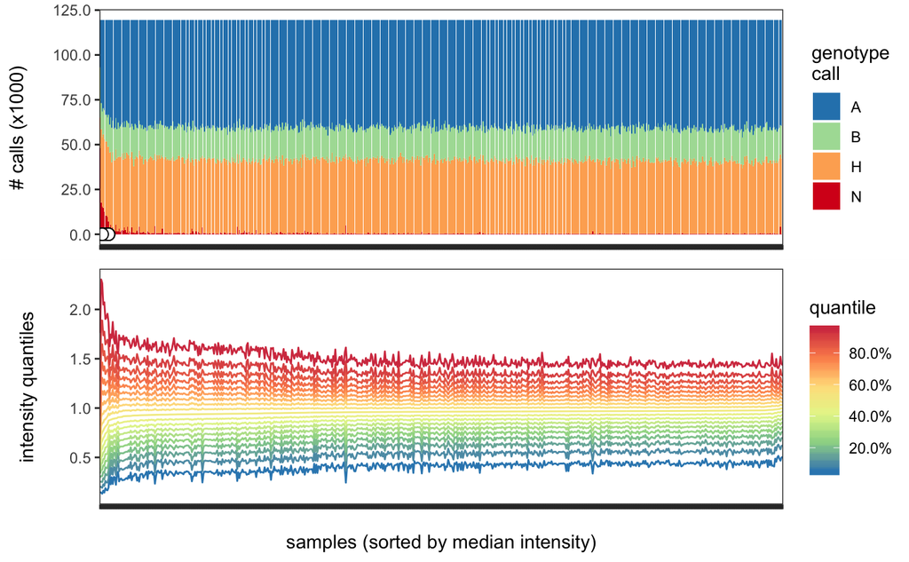

Which samples are bad?

```r
bad <-which(is.filtered(geno)$samples )
names(bad)
```

```
 [1] "265" "271" "291" "324" "346" "350" "352" "371" "4"   "667" "727"
```

Remove those samples

```r
geno = apply.filters(geno,apply.to = "both")
```

```
Dropping 0 markers and 11 samples...
```

Now lets do some marker level QC ##marker level QC

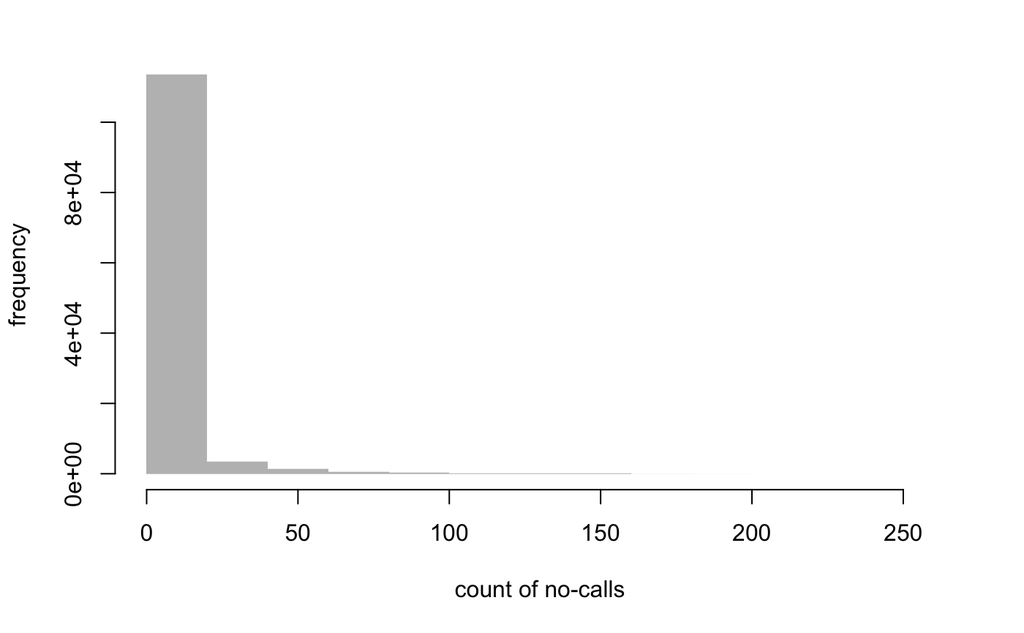

```r
calls <-summarize.calls(geno, "marker")
#no calls
hist(calls$N, col = "grey", border = NA,xlab = "count of no-calls", ylab = "frequency",main = NULL)
```

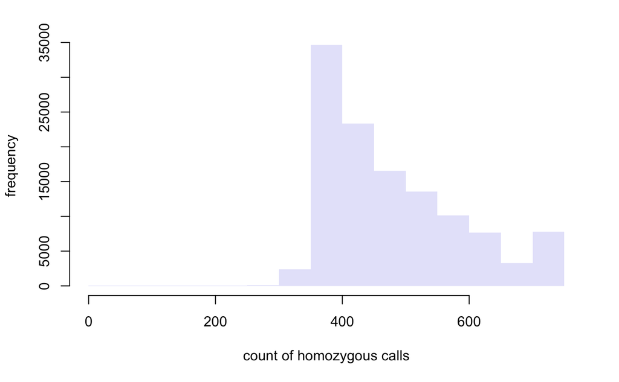

```r
#homozygous calls
hist(with(calls, A+B), col = "lavender", border = NA,xlab = "count of homozygous calls", ylab = "frequency",main = NULL)
```

Define max no calls and min homozygous calls based on plots

```r
geno <-run.marker.qc(geno, max.N = 75, min.hom = 300)
```

Apply the sample and marker level filters

```r
geno.final_merged <-apply.filters(geno,apply.to = "both")
```

```
Dropping 870 markers and 0 samples...
```

Output the geno file

```r
saveRDS(geno.final_merged, "../results/GIGAMUGA/geno.final_merged.RDS")
```

We now have genotypes for 733 samples across 118596 markers